# Protocolo de preparación y EDA: emergencias y daños en el Perú

Producto de la Unidad I | INDECI, 2019–2020

Autor/a

Ciencia de Datos e IA Aplicada

# 1 1. Contexto y pregunta de investigación

Los registros administrativos de emergencias del INDECI permiten explorar la distribución temporal y territorial de eventos reportados y sus consecuencias. El análisis se circunscribe a **2019–2020**: no permite inferir tendencias de 2015–2024 ni atribuir causalidad a factores no medidos.

**Pregunta de investigación:** ¿Cómo varían la frecuencia de registros de emergencias y la cantidad de personas damnificadas según el año, el departamento y el tipo de emergencia en el Perú durante 2019–2020?

**Hipótesis exploratorias (propuestas, no contrastes causales):**

- **H1.** La frecuencia de registros difiere entre 2019 y 2020.
- **H2.** Los registros de emergencias se distribuyen de manera desigual entre departamentos.
- **H3.** La distribución de personas damnificadas difiere entre tipos de emergencia.

Las conclusiones del EDA serán **provisionales y descriptivas**. Las diferencias observadas pueden reflejar tanto la incidencia de eventos como variaciones en el registro institucional.

# 2 2. Fuentes de datos y consideraciones éticas

**Fuente primaria:** Instituto Nacional de Defensa Civil (INDECI), *Base de datos de emergencia y daños con poblaciones vulnerables y grupos etáreos 2019–2020*. [Portal oficial](https://portal.indeci.gob.pe/direccion-politicas-y-planes/base-de-datos-de-emergencia-y-danos/base-de-datos-de-emergencia-y-danos-con-poblaciones-vulnerables-y-grupos-etareos-2019-2020/).

**Linaje:** archivo institucional `.xls` → conversión técnica a `.xlsx` sin edición intencional de registros → lectura con `readxl` → reglas explícitas de selección y derivación → CSV procesado. La conversión debe conservarse documentada y verificarse frente al archivo original.

Se analizan variables administrativas de evento y ubicación, sin incorporar identificadores personales. Antes de publicar cualquier versión ampliada se debe verificar que no incluya información que permita identificar personas y revisar las condiciones de reutilización y licencia de la fuente. No se dispone aquí de documentación sobre consentimiento individual; no se presume su existencia ni su necesidad para todos los registros agregados.

# 3 3. Limpieza e integración

La limpieza es **conservadora y reproducible**: no se imputan daños, no se eliminan atípicos y no se deduplican automáticamente códigos SINPAD. La base original se conserva separada.

Auditoría básica antes y después de preparar el dataset

| indicador | valor |
| --- | --- |
| Filas leídas del Excel | 21596 |
| Filas retenidas (2019–2020) | 21594 |
| Filas excluidas por reglas mínimas | 2 |
| Filas exactamente duplicadas en origen | 1 |
| Códigos SINPAD repetidos entre filas retenidas | 1 |
| Fechas no interpretables en base curada | 0 |
| Valores faltantes de damnificados | 0 |
| Valores negativos de damnificados | 0 |

Registro de decisiones de preparación

| decision | justificacion | alternativa_descartada | efecto |
| --- | --- | --- | --- |
| Conservar solo filas con año 2019/2020 y departamento y emergencia presentes | Separar filas no analíticas y mantener el periodo de estudio | Mantener filas sin información esencial | 2 filas excluidas |
| No eliminar registros por ID_SINPAD repetido | Un código repetido no prueba duplicación de observaciones | Eliminar automáticamente todos los IDs repetidos | No se eliminan por este motivo |
| Mantener faltantes y ceros en variables de daños | Cero y ausencia de dato no son equivalentes | Imputar cero o mediana sin justificación | Ninguna imputación |
| No eliminar valores extremos | Los eventos extremos son sustantivos en desastres | Recortar percentiles sin criterio | Ninguna eliminación |
| Derivar año, mes y etiquetas estandarizadas | Facilitar el análisis reproducible | Usar etiquetas sin normalización | Se crean variables derivadas |

Faltantes por variable en el dataset procesado

|  | variable | n_faltantes | porcentaje |
| --- | --- | --- | --- |
| ID_SINPAD | ID_SINPAD | 0 | 0 |
| FECHA_PARSEADA | FECHA_PARSEADA | 0 | 0 |
| ANIO | ANIO | 0 | 0 |
| MES_NUM | MES_NUM | 0 | 0 |
| COD_DISTRITO | COD_DISTRITO | 0 | 0 |
| DEPARTAMENTO | DEPARTAMENTO | 0 | 0 |
| PROV | PROV | 0 | 0 |
| DIST | DIST | 0 | 0 |
| TIPO_EMERGENCIA | TIPO_EMERGENCIA | 0 | 0 |
| PERSONAS_AFECTADAS | PERSONAS_AFECTADAS | 0 | 0 |
| PERSONAS_DAMNIFICADAS | PERSONAS_DAMNIFICADAS | 0 | 0 |
| PERSONAS_FALLECIDAS | PERSONAS_FALLECIDAS | 0 | 0 |
| PERSONAS_LESIONADAS | PERSONAS_LESIONADAS | 0 | 0 |

No se integran fuentes externas: el trabajo usa un único archivo institucional. El cruce con censos, clima o población se plantea como trabajo futuro y exigiría comprobar compatibilidad espacial y temporal.

# 4 4. Ingeniería de características

Se derivan `ANIO`, `MES_NUM`, `DEPARTAMENTO`, `TIPO_EMERGENCIA` y los indicadores numéricos de afectación, damnificación, fallecimientos y lesiones. La fecha se interpreta como día/mes/año. Los códigos territoriales se conservan como identificadores y no como magnitudes numéricas.

Variables seleccionadas para análisis y futuro modelado

|  | variable | tipo | faltantes |
| --- | --- | --- | --- |
| ID_SINPAD | ID_SINPAD | numeric | 0 |
| FECHA_PARSEADA | FECHA_PARSEADA | Date | 0 |
| ANIO | ANIO | integer | 0 |
| MES_NUM | MES_NUM | integer | 0 |
| COD_DISTRITO | COD_DISTRITO | character | 0 |
| DEPARTAMENTO | DEPARTAMENTO | character | 0 |
| PROV | PROV | character | 0 |
| DIST | DIST | character | 0 |
| TIPO_EMERGENCIA | TIPO_EMERGENCIA | character | 0 |
| PERSONAS_AFECTADAS | PERSONAS_AFECTADAS | numeric | 0 |
| PERSONAS_DAMNIFICADAS | PERSONAS_DAMNIFICADAS | numeric | 0 |
| PERSONAS_FALLECIDAS | PERSONAS_FALLECIDAS | numeric | 0 |
| PERSONAS_LESIONADAS | PERSONAS_LESIONADAS | numeric | 0 |

No se aplican PCA, t-SNE, UMAP, Boruta ni RFE: no son necesarios para este EDA y su uso requeriría definir una tarea predictiva y una validación apropiada. Tampoco se realiza escalamiento ni imputación. Si se aplicaran en la Unidad II, sus parámetros deberán estimarse **dentro de cada partición de entrenamiento** para evitar fuga de información.

# 5 5. Análisis exploratorio orientado a hipótesis

## 5.1 H1. Comparación temporal 2019–2020

Frecuencia anual de registros

| anio | registros |
| --- | --- |
| 2019 | 11190 |
| 2020 | 10404 |

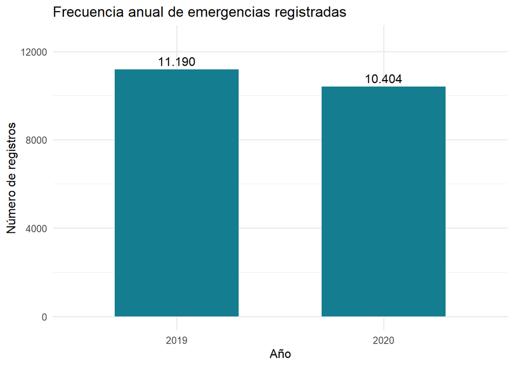

Registros de emergencias por año (conteos de filas del dataset)

## 5.2 H2. Distribución geográfica

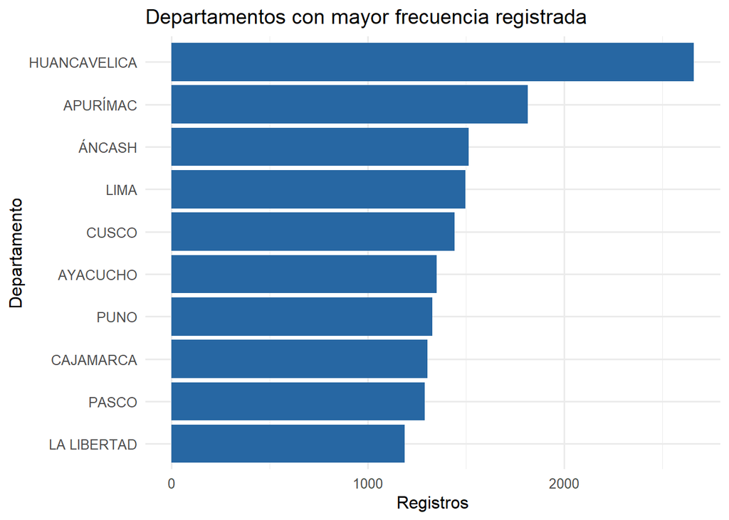

Diez departamentos con más registros de emergencias

## 5.3 H3. Damnificados por tipo de emergencia

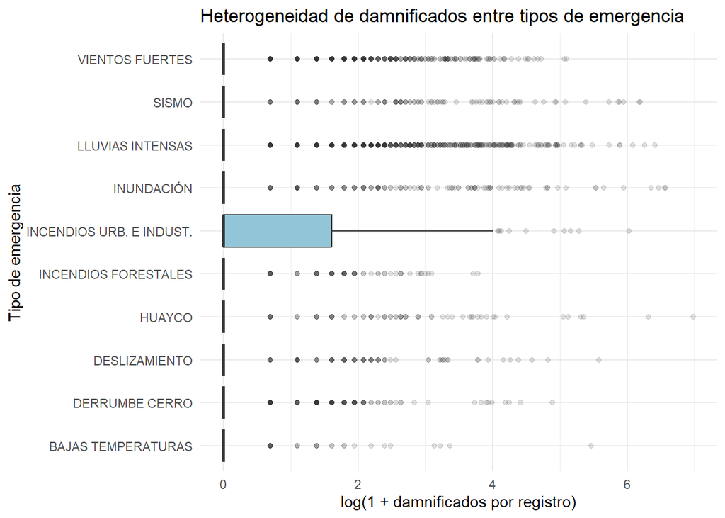

Distribución de damnificados por tipo de emergencia (10 tipos más frecuentes; escala log1p)

Resumen de damnificados por tipo de emergencia

|  | tipo | n | mediana | p95 | total |
| --- | --- | --- | --- | --- | --- |
| 15 | LLUVIAS INTENSAS | 6369 | 0 | 8.0 | 15624 |
| 13 | INCENDIOS URB. E INDUST. | 2359 | 0 | 11.0 | 7515 |
| 14 | INUNDACIÓN | 1094 | 0 | 15.3 | 6789 |
| 20 | SISMO | 444 | 0 | 52.0 | 5125 |
| 21 | VIENTOS FUERTES | 2486 | 0 | 10.8 | 5111 |
| 11 | HUAYCO | 747 | 0 | 9.7 | 3306 |
| 7 | DESLIZAMIENTO | 1263 | 0 | 3.0 | 1388 |
| 6 | DERRUMBE CERRO | 917 | 0 | 5.0 | 1083 |
| 1 | ACTIVIDAD VOLCÁNICA | 33 | 0 | 82.8 | 817 |
| 2 | ALUD | 6 | 0 | 488.2 | 651 |
| 12 | INCENDIOS FORESTALES | 2018 | 0 | 0.0 | 498 |
| 17 | OTROS | 374 | 0 | 5.0 | 447 |

**Interpretación:** la escala `log(1+x)` facilita visualizar distribuciones con muchos ceros y valores elevados. Los boxplots permiten explorar dispersión, asimetría y diferencias, pero **no constituyen una prueba inferencial**. La conclusión de H3 es provisional; requiere comprobar independencia y unidad de observación antes de contrastar formalmente grupos.

## 5.4 EDA complementario: calidad y distribuciones

El EDA examina la **unidad de observación (fila administrativa)**, la completitud, la concentración de registros, la variación mensual y la distribución de damnificados. Los gráficos no deben interpretarse como tasas poblacionales ni como efectos causales.

### 5.4.1 Perfil de datos faltantes

[figure not shown]

Figura 1: Porcentaje de datos faltantes en las variables del conjunto procesado

La proporción de faltantes es una medida de calidad, no una prueba de que los valores ausentes sean aleatorios. No se sustituyeron faltantes por cero.

### 5.4.2 Frecuencia mensual por año

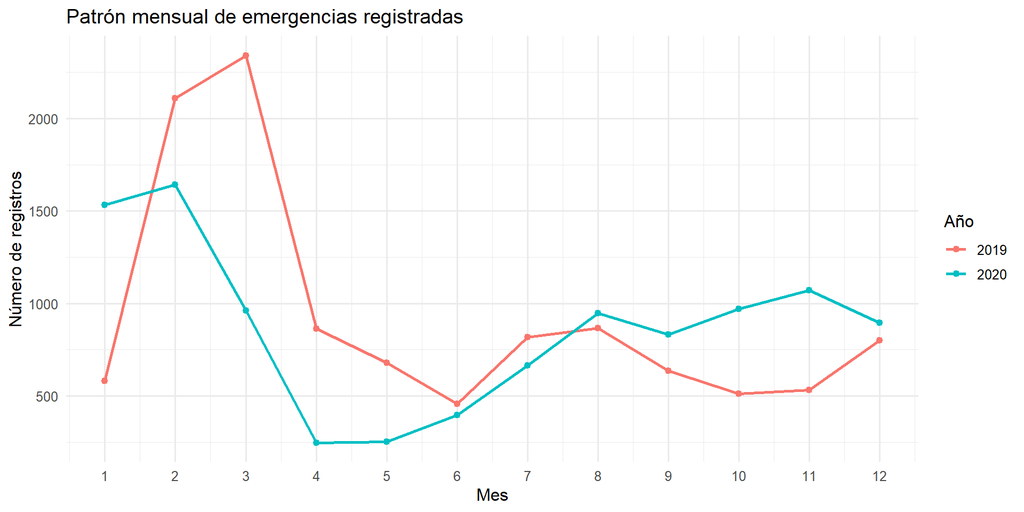

Figura 2: Registros mensuales de emergencias por año, 2019–2020

### 5.4.3 Tipos de emergencia más frecuentes

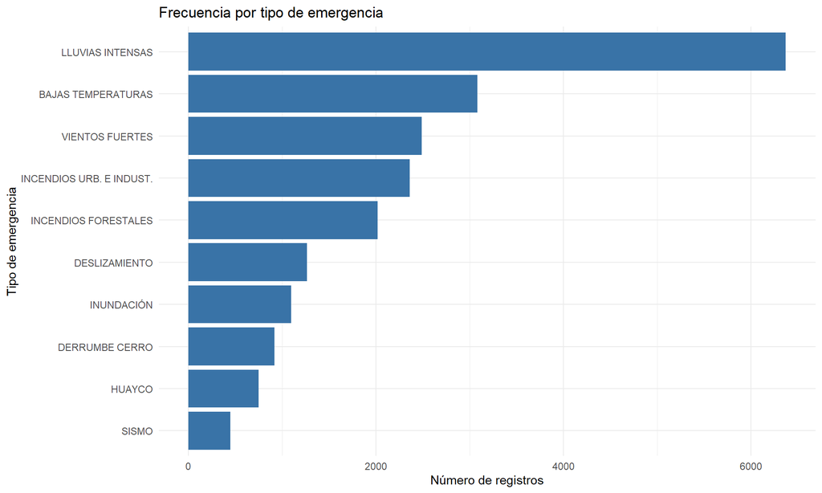

Figura 3: Diez tipos de emergencia con más registros administrativos

### 5.4.4 Distribución de damnificados por registro

Tabla 1: Medidas descriptivas de personas damnificadas por registro válido

| indicador | valor |
| --- | --- |
| Registros con dato válido | 21594.00 |
| Porcentaje con cero | 86.55 |
| Media | 2.27 |
| Mediana | 0.00 |
| P75 | 0.00 |
| P95 | 7.00 |
| Máximo | 1078.00 |

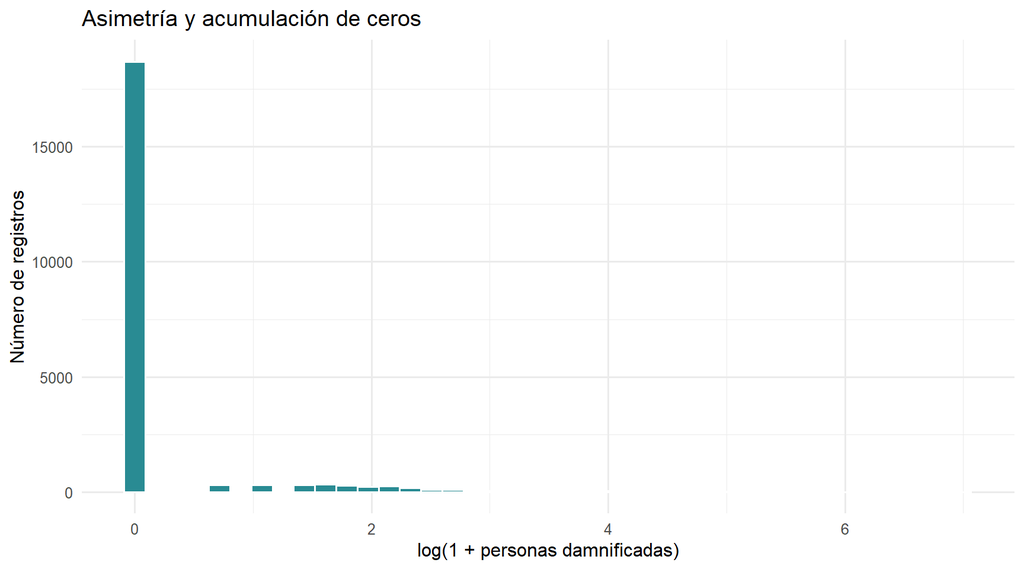

Figura 4: Distribución de damnificados por registro (transformación log1p)

El logaritmo se usa **solo para visualización**, no altera el CSV procesado. Una concentración en cero y una cola derecha prolongada sugerirían explorar modelos de conteo o modelos con exceso de ceros, sujetos a verificación posterior.

### 5.4.5 Concentración territorial de registros

Tabla 2: Participación de los diez departamentos con más registros

| departamento | registros | porcentaje |
| --- | --- | --- |
| HUANCAVELICA | 2660 | 12.32 |
| APURÍMAC | 1814 | 8.40 |
| ÁNCASH | 1513 | 7.01 |
| LIMA | 1497 | 6.93 |
| CUSCO | 1440 | 6.67 |
| AYACUCHO | 1349 | 6.25 |
| PUNO | 1327 | 6.15 |
| CAJAMARCA | 1302 | 6.03 |
| PASCO | 1290 | 5.97 |
| LA LIBERTAD | 1188 | 5.50 |

**Precaución:** los conteos por departamento no están ajustados por población, superficie, exposición a amenazas ni capacidad de notificación. Por ello, el ranking no equivale a un ranking de riesgo.

### 5.4.6 Asociación exploratoria: año y tipo de emergencia

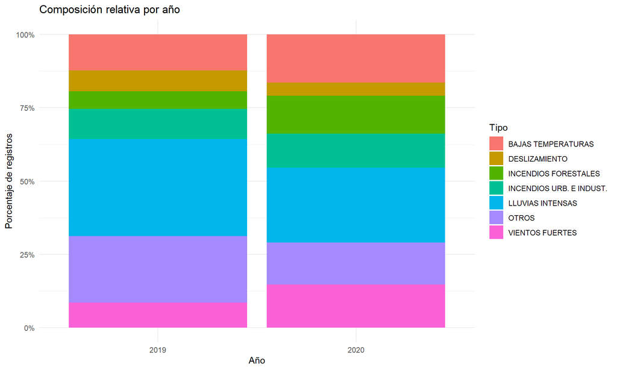

Figura 5: Composición porcentual de los tipos de emergencia más frecuentes según año

Esta visualización compara **proporciones**, no volúmenes absolutos. Los cambios pueden reflejar modificaciones en la notificación institucional.

### 5.4.7 Síntesis de hipótesis exploratorias

Tabla 3: Síntesis descriptiva de las hipótesis y limitaciones

| hipotesis | evidencia | conclusion | limitacion |
| --- | --- | --- | --- |
| H1: diferencias entre años | Conteos anuales y mensuales | Diferencia descriptiva observada | Dos años; cobertura del registro |
| H2: distribución territorial desigual | Ranking y participación departamental | Concentración descriptiva observada | Sin ajuste por población o exposición |
| H3: damnificados por tipo | Boxplot log1p y resumen por tipo | Exploración visual; no se ejecuta contraste inferencial | Posible dependencia y ceros; no implica causalidad |

Las conclusiones son provisionales. No se declara confirmación estadística de hipótesis mediante gráficos descriptivos.

# 6 6. Hallazgos y decisiones para la Unidad II

**Unidad de análisis:** registro administrativo de emergencia. No se presume que cada fila represente necesariamente un evento único sin revisar la definición oficial del identificador SINPAD.

**Propuesta de modelado:** predecir el número de personas damnificadas por registro, mediante modelos de conteo o enfoques adecuados a datos con exceso de ceros. Esta propuesta queda sujeta a evaluación de la distribución y a la disponibilidad de predictores conocidos antes del evento.

**Variables candidatas:** año, mes, departamento, provincia/distrito y tipo de emergencia, tras evaluar su calidad y temporalidad. **Variable respuesta:** `PERSONAS_DAMNIFICADAS`.

**Riesgos y decisiones:**

- **Fuga de información:** no utilizar como predictores los daños observados después del evento (`PERSONAS_AFECTADAS`, fallecidos, lesionados) para una predicción anticipada.
- **Dependencia:** registros del mismo lugar, evento o fecha podrían no ser independientes; revisar duplicidad de identificadores y definir particiones temporales o agrupadas.
- **Desbalance y ceros:** cuantificar registros con cero damnificados antes de elegir el modelo y las métricas.
- **Cobertura temporal:** solo dos años; cualquier generalización a otros periodos debe considerarse limitada.
- **Preprocesamiento:** imputación, codificación entrenable y escalamiento se ajustarán exclusivamente con los datos de entrenamiento en validación cruzada.

# 7 7. Reproducibilidad, limitaciones y ética

El archivo original `.xls` se preserva fuera del proceso de modificación. La copia `.xlsx` es un insumo técnico para `readxl`; el script de este Quarto genera `data/procesado/emergencias_2019_2020_curado.csv` en cada ejecución. Las decisiones se documentan en la sección 3. El archivo debe publicarse solo tras comprobar licencia y ausencia de datos personales identificables.

**Uso de IA generativa:** se utilizó ChatGPT como apoyo para estructurar el protocolo, redactar explicaciones y elaborar código Quarto/R. Los datos proceden del INDECI; los resultados deben verificarse mediante la ejecución del código y la revisión académica correspondiente.

# 8 Referencia

Instituto Nacional de Defensa Civil (INDECI). (s. f.). *Base de datos de emergencia y daños con poblaciones vulnerables y grupos etáreos 2019–2020*. [Portal institucional](https://portal.indeci.gob.pe/direccion-politicas-y-planes/base-de-datos-de-emergencia-y-danos/base-de-datos-de-emergencia-y-danos-con-poblaciones-vulnerables-y-grupos-etareos-2019-2020/).